# sassy

The **sassy** package is a meta-package that aims to make R easier for everyone, especially people with a background in SAS®. The package brings several useful SAS® concepts to R, including data libraries, formats and format catalogs, data dictionaries, a data step, a traceable log, and a reporting package with a variety of printable report types.

The core of the **sassy** system is the **procs** package. This package contains replications of several SAS® procedures: `proc_freq()`, `proc_means()`, `proc_ttest()`, `proc_reg()`, `proc_transpose()`, and `proc_sort()`. Combined with the `datastep()` function from the **libr** package, you can write code in R that very much resembles what you would write in SAS®. These functions provide a higher-level programming interface than is typically found in R, and can therefore make your analysis more efficient and productive.

### Included Packages

The **sassy** meta-package contains the following packages:

- **[logr](https://logr.r-sassy.org)**: Produces a traceable log
- **[fmtr](https://fmtr.r-sassy.org)**: Provides functions for formatting data and a creating a format catalog
- **[libr](https://libr.r-sassy.org)**: Gives you the ability to define a libname, generate a data dictionary, and simulate a data step
- **[reporter](https://reporter.r-sassy.org)**: A reporting package with easy layout capabilities and the ability to write reports in TXT, RTF, PDF, HTML, and DOCX file formats
- **[common](https://common.r-sassy.org)**: A set of utility functions shared across the **sassy** family of packages, and often useful in their own right.
- **[procs](https://procs.r-sassy.org)**: A set of functions that simulate SAS® procedures. Package includes simulations of PROC FREQ, PROC MEANS, PROC TRANSPOSE, PROC SORT, and PROC PRINT.
- **[macro](https://macro.r-sassy.org)**: A macro language for R that allows easy, text-based meta-programming.

The above links will take you into the respective packages for a deep dive on their capabilities.

### Next Steps

Before taking a deep dive into the **sassy** package documentation, please look at some examples. These examples will give you a feel for the overall flow of a **sassy**-enhanced program, and allow you to see how the functions work together.

The following examples are provided on this site:

- **Example 1**: Creates a simple data listing and log

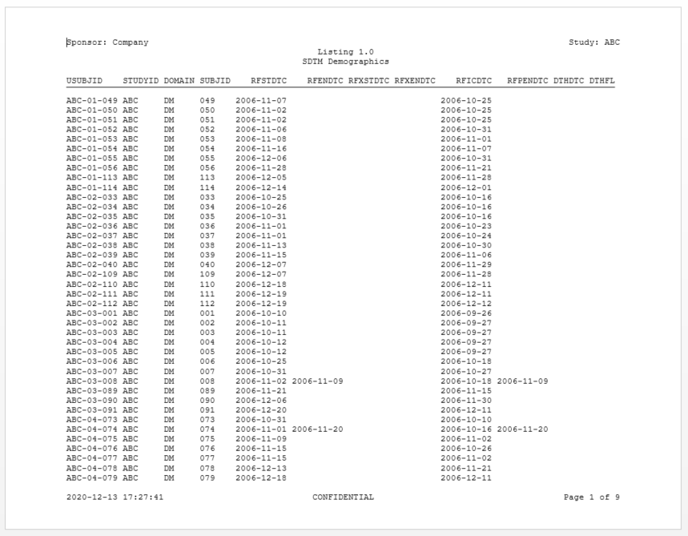

- **Example 2**: Creates a table of demographic characteristics

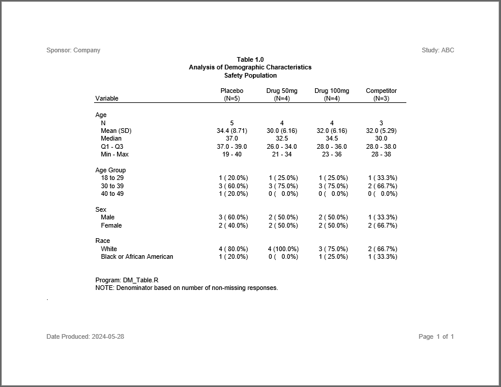

- **Example 3**: Creates a simple figure

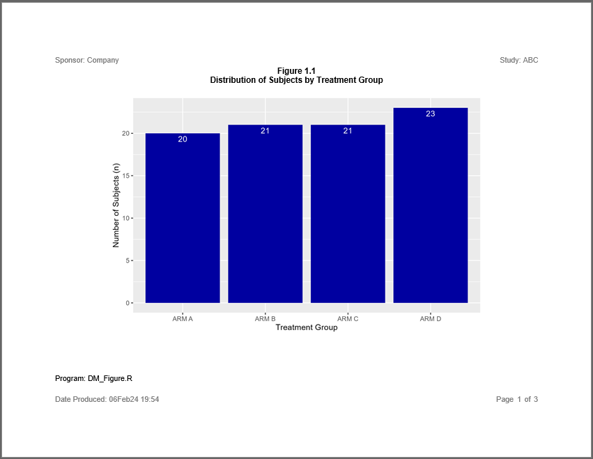

- **Example 4**: Creates an AE table with a page wrap

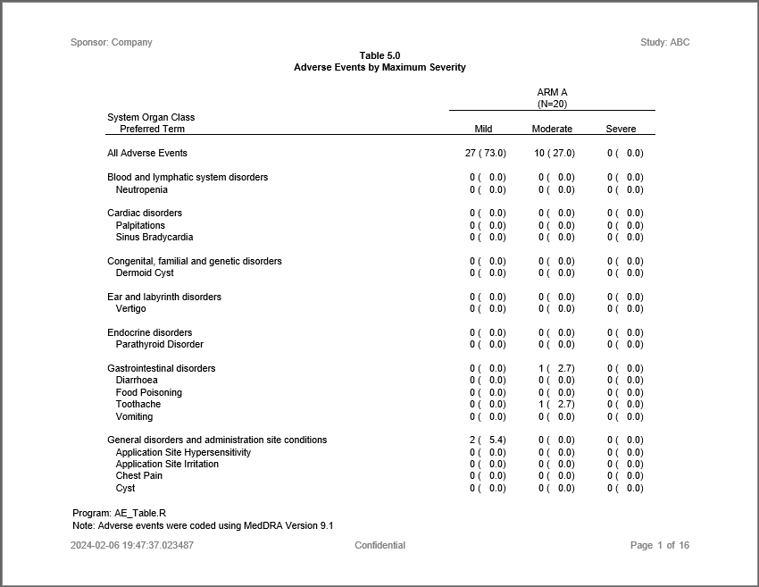

- **Example 5**: Creates a table of vital signs statistics

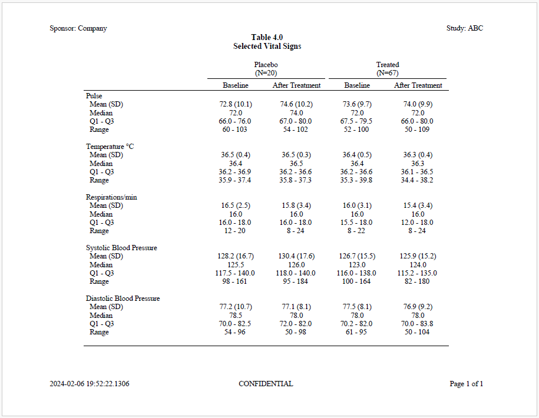

- **Example 6**: Creates a figure with a by-group

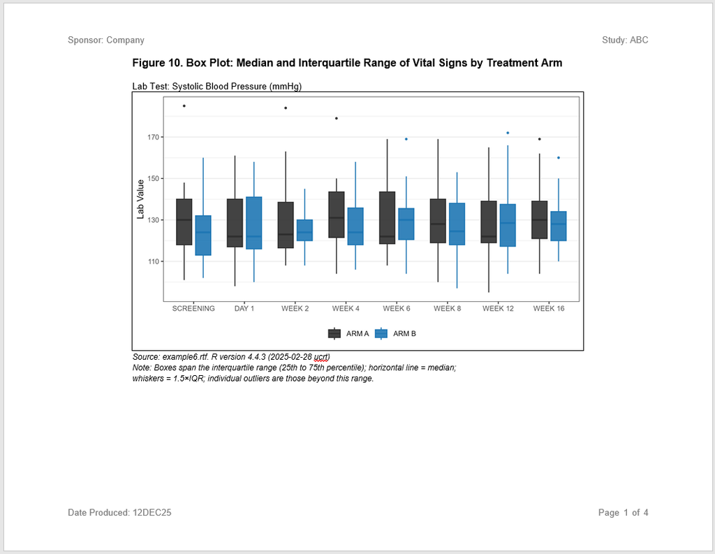

- **Example 7**: Perform survival analysis.

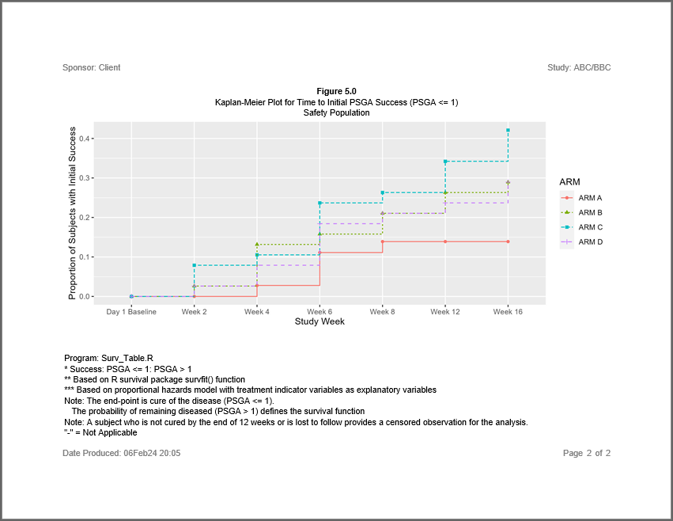

- **Example 8**: Creates a patient profile report.

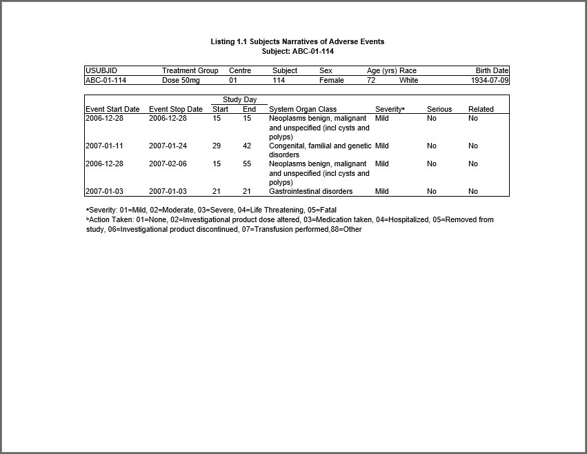

- **Example 9**: Creates a figure with a forest plot.

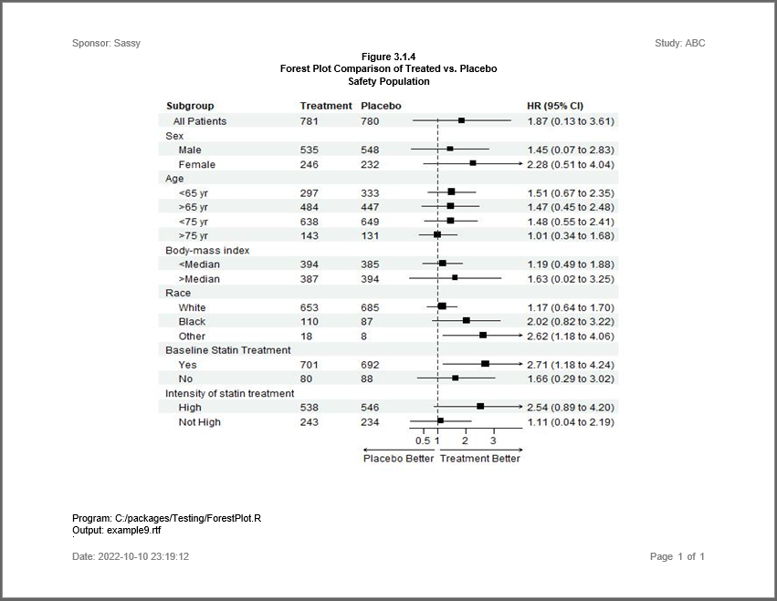

- **Example 10**: Creates a subject disposition table.

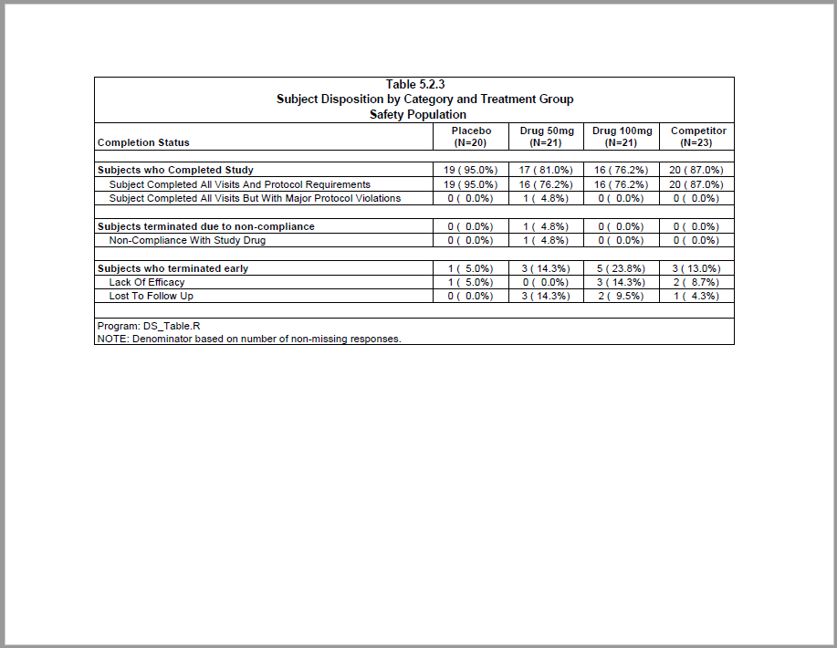

- **Example 11**: Creates a subject listing with vital signs by visit.

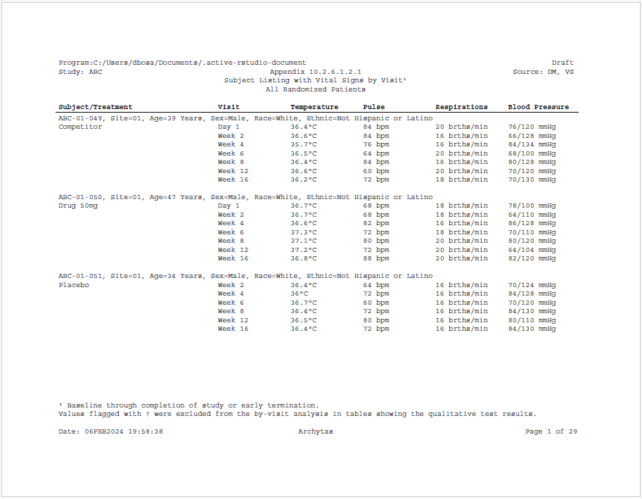

- **Example 12**: Creates a combined figure of age groups by treatment.

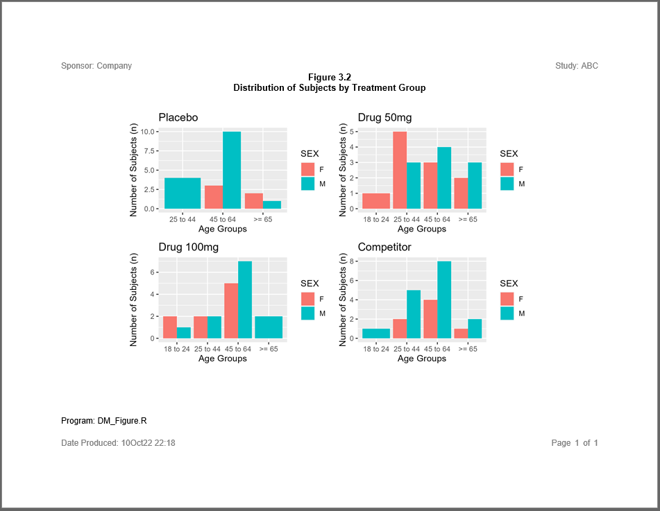

- **Example 13**: Creates a Mean Change from Baseline figure for laboratory values.

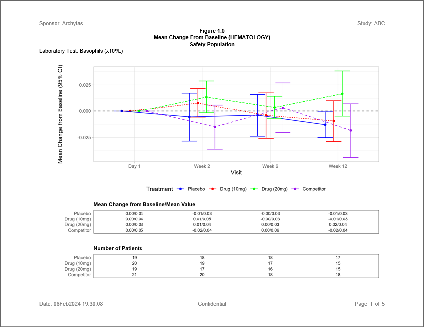

- **Example 14**: Creates an AE table with severity grades in rows

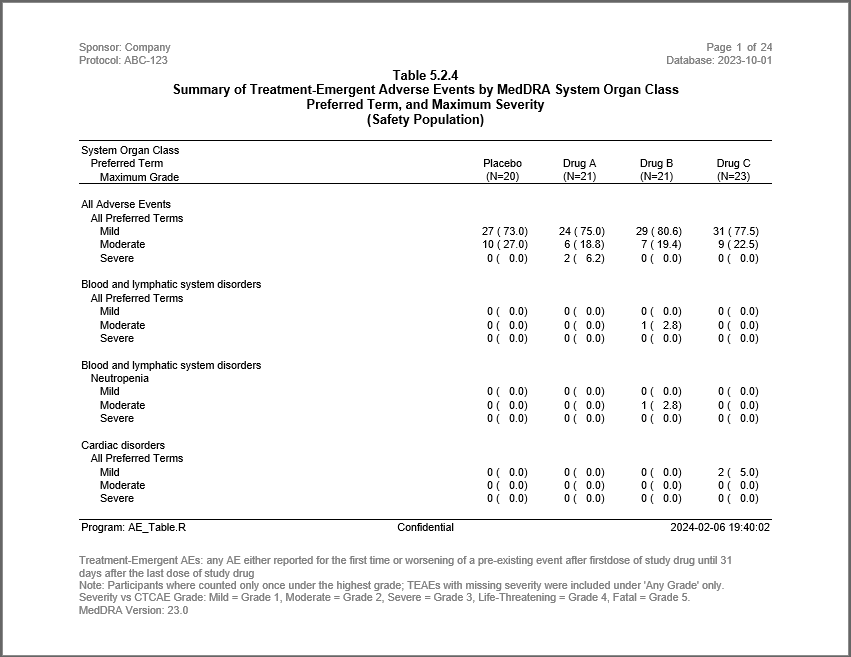

- **Example 15**: Creates both stand-alone and “intext” versions of a demographics table.

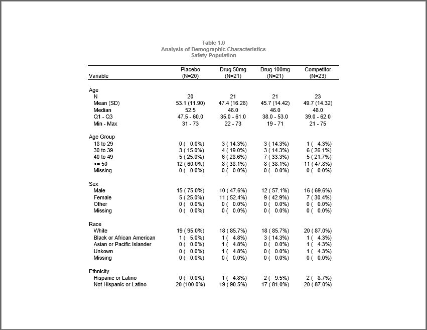

- **Example 16**: Creates a shift table of lab values.

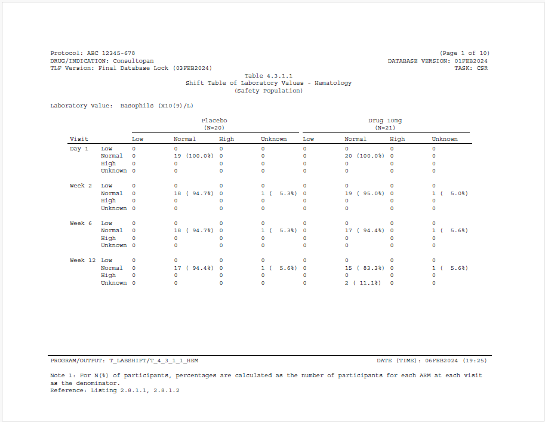

Once you review these examples, please proceed to the package links above to explore the system further!